# Tidy Tuesday

Week 33

Author

Cristian T

Published

August 20, 2024

```r
# Load the tidytuesday package
suppressMessages(library(tidytuesdayR))
suppressMessages(library(skimr))
suppressMessages(library(tidyverse))
suppressMessages(library(dplyr))


# Load the current week's dataset
tuesdata <- tidytuesdayR::tt_load('2024-08-13')
worlds_fairs <- tuesdata$worlds_fairs

# Explore the structure of the dataset
str(worlds_fairs)
```

```
spc_tbl_ [70 × 14] (S3: spec_tbl_df/tbl_df/tbl/data.frame)
 $ start_month        : num [1:70] 4 5 5 4 5 5 5 10 4 5 ...
 $ start_year         : num [1:70] 1851 1855 1862 1867 1873 ...
 $ end_month          : num [1:70] 10 11 11 11 10 11 11 4 12 10 ...
 $ end_year           : num [1:70] 1851 1855 1862 1867 1873 ...
 $ name_of_exposition : chr [1:70] "The Great Exhibition" "Exposition Universelle / Paris International" "International Exhibition" "Exposition Universelle / Paris International" ...
 $ country            : chr [1:70] "United Kingdom" "France" "United Kingdom" "France" ...
 $ city               : chr [1:70] "London" "Paris" "London" "Paris" ...
 $ category           : chr [1:70] "World Expo" "World Expo" "World Expo" "World Expo" ...
 $ theme              : chr [1:70] "Industry of all Nations" "Agriculture, Industry and Arts" "Industry and Arts" "Agriculture, Industry and Arts" ...
 $ notables           : chr [1:70] "The Crystal Palace" "Palais d'Industrie, Bordeaux Wine classification" NA "Champ de Mars" ...
 $ visitors           : num [1:70] 6 5 6 15 7.25 10 16 1.3 2.3 32 ...
 $ cost               : num [1:70] 165 2 2 45 95 8 11 16 17 3 ...
 $ area               : num [1:70] 10 15 15 69 233 115 75 25 47 96 ...
 $ attending_countries: num [1:70] 25 25 39 42 35 35 36 33 30 35 ...
 - attr(*, "spec")=
  .. cols(
  ..   start_month = col_double(),
  ..   start_year = col_double(),
  ..   end_month = col_double(),
  ..   end_year = col_double(),
  ..   name_of_exposition = col_character(),
  ..   country = col_character(),
  ..   city = col_character(),
  ..   category = col_character(),
  ..   theme = col_character(),
  ..   notables = col_character(),
  ..   visitors = col_double(),
  ..   cost = col_double(),
  ..   area = col_double(),
  ..   attending_countries = col_double()
  .. )
 - attr(*, "problems")=<externalptr>
```

```r
skim(worlds_fairs)
```

Data summary

| Name | worlds_fairs |
| --- | --- |
| Number of rows | 70 |
| Number of columns | 14 |
| _______________________ |  |
| Column type frequency: |  |
| character | 6 |
| numeric | 8 |
| ________________________ |  |
| Group variables | None |

**Variable type: character**

| skim_variable | n_missing | complete_rate | min | max | empty | n_unique | whitespace |
| --- | --- | --- | --- | --- | --- | --- | --- |
| name_of_exposition | 0 | 1.00 | 5 | 101 | 0 | 67 | 0 |
| country | 0 | 1.00 | 5 | 26 | 0 | 24 | 0 |
| city | 0 | 1.00 | 4 | 14 | 0 | 51 | 0 |
| category | 0 | 1.00 | 10 | 16 | 0 | 2 | 0 |
| theme | 0 | 1.00 | 5 | 77 | 0 | 68 | 0 |
| notables | 11 | 0.84 | 3 | 83 | 0 | 58 | 0 |

**Variable type: numeric**

| skim_variable | n_missing | complete_rate | mean | sd | p0 | p25 | p50 | p75 | p100 | hist |
| --- | --- | --- | --- | --- | --- | --- | --- | --- | --- | --- |
| start_month | 0 | 1.00 | 5.41 | 1.88 | 2.00 | 4.00 | 5.0 | 6.00 | 12.00 | ▅▇▂▁▁ |
| start_year | 0 | 1.00 | 1947.19 | 44.26 | 1851.00 | 1911.50 | 1953.5 | 1983.50 | 2021.00 | ▃▅▆▇▅ |
| end_month | 0 | 1.00 | 9.16 | 2.38 | 1.00 | 9.00 | 10.0 | 11.00 | 12.00 | ▁▁▁▃▇ |
| end_year | 0 | 1.00 | 1947.29 | 44.26 | 1851.00 | 1911.50 | 1953.5 | 1983.50 | 2022.00 | ▃▅▆▇▅ |
| visitors | 14 | 0.80 | 16.64 | 16.59 | 0.80 | 5.64 | 10.0 | 21.63 | 73.08 | ▇▃▁▁▁ |
| cost | 34 | 0.51 | 559.94 | 998.43 | 2.00 | 26.75 | 125.5 | 448.25 | 4200.00 | ▇▁▁▁▁ |
| area | 5 | 0.93 | 105.82 | 116.99 | 0.08 | 30.00 | 70.0 | 120.00 | 523.00 | ▇▂▁▁▁ |
| attending_countries | 5 | 0.93 | 49.22 | 45.04 | 8.00 | 23.00 | 33.0 | 55.00 | 192.00 | ▇▂▁▁▁ |

```r
# View the first few rows of the dataset
head(worlds_fairs)
```

| start_month | start_year | end_month | end_year | name_of_exposition | country | city | category | theme | notables | visitors | cost | area | attending_countries |
| --- | --- | --- | --- | --- | --- | --- | --- | --- | --- | --- | --- | --- | --- |
| 4 | 1851 | 10 | 1851 | The Great Exhibition | United Kingdom | London | World Expo | Industry of all Nations | The Crystal Palace | 6.00 | 165 | 10 | 25 |
| 5 | 1855 | 11 | 1855 | Exposition Universelle / Paris International | France | Paris | World Expo | Agriculture, Industry and Arts | Palais d'Industrie, Bordeaux Wine classification | 5.00 | 2 | 15 | 25 |
| 5 | 1862 | 11 | 1862 | International Exhibition | United Kingdom | London | World Expo | Industry and Arts | NA | 6.00 | 2 | 15 | 39 |
| 4 | 1867 | 11 | 1867 | Exposition Universelle / Paris International | France | Paris | World Expo | Agriculture, Industry and Arts | Champ de Mars | 15.00 | 45 | 69 | 42 |
| 5 | 1873 | 10 | 1873 | Weltausstellung 1873 Wien / Austrian International Exposition | Austria-Hungary | Vienna | World Expo | Culture and Education | Rotunde | 7.25 | 95 | 233 | 35 |
| 5 | 1876 | 11 | 1876 | Centennial Exposition | United States | Philadelphia | World Expo | Arts, Manufactures and Products of the Soil and Mine | Centennial Arboretum, Telephone, Heinz Ketchup | 10.00 | 8 | 115 | 35 |

```r
#tidytuesdayR::use_tidytemplate()
```

#### Missing Values

Notables: 11 missing values (about 15.7% of the rows). Visitors: 14 missing values (about 20% of the rows). Cost: 34 missing values (about 48.6% of the rows). Area: 5 missing values (about 7.1% of the rows). Attending Countries: 5 missing values (about 7.1% of the rows). Most of the cost fetched from https://jdpecon.com/expo/expolist.html

# Clean the data

```r
#selected_data <- worlds_fairs %>% dplyr::select("country", "start_year", "city", "cost")
#selected_data

# add missing values
# https://jdpecon.com/expo/expolist.html
worlds_fairs[70, "cost"] <- 14600 # Dubai 2022
worlds_fairs[69, "cost"] <- 3000 # Kazakhstan 2017
worlds_fairs[68, "cost"] <- 1640 # Italy 2015
worlds_fairs[65, "cost"] <- 1070 # Spain 2008
worlds_fairs[64, "cost"] <- 3130 # Japan 2005
worlds_fairs[62, "cost"] <- 2952 # Portugal 1998 | Estimated $1753 to $2398 million - We will use median 2952 rounded
worlds_fairs[61, "cost"] <- 2800 # South Korea 1993
worlds_fairs[60, "cost"] <- 568.75 # Italy 1992 $487.5 to $650 million according to the New York Times - We will use median 568.75 rounded
worlds_fairs[59, "cost"] <- 2332 # Spain 1992
worlds_fairs[54, "cost"] <- 763.7 # Japan 1985
worlds_fairs[50, "cost"] <- 304 # Japan 1975
worlds_fairs[12, "cost"] <- 1.14 # Belgium 1897


# Corrections
# https://jdpecon.com/expo/expolist.html
worlds_fairs[1, "cost"] <- 1.67 # London 1851
worlds_fairs[2, "cost"] <- 5.7 # France 1855
worlds_fairs[3, "cost"] <- 2.3 # London 1862
worlds_fairs[4, "cost"] <- 4.5 # Paris 1867
worlds_fairs[5, "cost"] <- 12 # Vienna 1873
worlds_fairs[6, "cost"] <- 9 # Philadelphia 1876
# worlds_fairs[7, "cost"] <- 11 # France 1878
worlds_fairs[8, "cost"] <- 1.56 # Melbourne 1880
worlds_fairs[9, "cost"] <- 1.7 # Spain 1881
worlds_fairs[10, "cost"] <- 8.01 # France 1889 41.5 million French francs would be approximately 8.01 million USD
worlds_fairs[11, "cost"] <- 27.3 # Chicago 1893
worlds_fairs[12, "cost"] <- 1.14 # Belgium  1897
worlds_fairs[13, "cost"] <- 18.75 # Paris 1900
worlds_fairs[14, "cost"] <- 26.5 # St Louis 1904
worlds_fairs[15, "cost"] <- 2.89 # Belgium 1905
worlds_fairs[16, "cost"] <- 2.6 # Milan 1906
worlds_fairs[17, "cost"] <- 3.55 # Belgium  1910
# worlds_fairs[18, "cost"] <- NA # Italy    1911
worlds_fairs[19, "cost"] <- 3.3 # Belgium   1913
worlds_fairs[20, "cost"] <- 24.7 # San Francisco    1915
# worlds_fairs[21, "cost"] <- 25 # Spain    1929
worlds_fairs[22, "cost"] <- 31 # Chicago 1933
worlds_fairs[23, "cost"] <- 22.4 # Belgium 1935
# worlds_fairs[24, "cost"] <- NA # Sweden   1936
worlds_fairs[25, "cost"] <- 57.25 # Paris 1937
# worlds_fairs[26, "visitors"] <- NA # Finland  1938
worlds_fairs[27, "cost"] <- 160 # New York City 1939
worlds_fairs[27, "attending_countries"] <- 52 # New York City 1939

# https://en.worldfairs.info/expodonnees.php?expo_id=32
worlds_fairs[28, "area"] <- 80 # Belgium    1939
worlds_fairs[28, "visitors"] <- 1.7 # Belgium   1939
worlds_fairs[28, "cost"] <- 58.51 # Belgium 1939 | 150 million Belgian francs would be approximately $58.51 million 2015 dollars

# worlds_fairs[29, "cost"] <- NA # France   1947
# worlds_fairs[30, "cost"] <- NA # Sweden   1949
# worlds_fairs[31, "cost"] <- NA # France   1949

# https://www.bie-paris.org/site/en/latest/blog/entry/cultivating-tourism-in-haiti-the-bicentennial-international-exposition-of-port-au-prince-1949
worlds_fairs[32, "cost"] <- 4 # Expo Port-au-Prince 1949
worlds_fairs[32, "visitors"] <- 0.07 # Expo Port-au-Prince 1949
# worlds_fairs[33, "cost"] <- NA # France   1951
# worlds_fairs[34, "cost"] <- NA # Italy    1953
worlds_fairs[35, "visitors"] <- 0.6 # Expo 1953 Jerusalem
# worlds_fairs[36, "cost"] <- NA # Italy    1954
worlds_fairs[37, "visitors"] <- 0.12 # Italy    1955
# worlds_fairs[38, "cost"] <- NA # Sweden   1955
# worlds_fairs[39, "cost"] <- NA # Israel   1956
# worlds_fairs[40, "cost"] <- NA # West Germany 1957
worlds_fairs[41, "cost"] <- 43.4 # Belgium  1958
# worlds_fairs[42, "cost"] <- NA # Italy    1961
worlds_fairs[43, "cost"] <- 22.8 # Seattle 1962
# worlds_fairs[44, "cost"] <- NA # West Germany 1965
worlds_fairs[45, "cost"] <- 384.7 # 1967 Canada 415.920 CAD million would be approximately 384.7 million USD
# worlds_fairs[46, "cost"] <- 156.00 # San Antonio 1968
worlds_fairs[47, "cost"] <- 247.54 # Japan  1970
# worlds_fairs[48, "cost"] <- NA # Hungary  1971
worlds_fairs[49, "cost"] <- 78.40 # Spokane 1974
worlds_fairs[50, "cost"] <- 155.2 # Japan   1975
# worlds_fairs[51, "cost"] <- NA # Bulgaria 1981
worlds_fairs[52, "cost"] <- 111 # Knoxville 1982
worlds_fairs[53, "cost"] <- 442.5 # New Orleans 1984
worlds_fairs[54, "cost"] <- 763.7 # Japan   1985
# worlds_fairs[55, "cost"] <- NA # Bulgaria 1985
worlds_fairs[56, "cost"] <- 609.52 # Canada 1986
worlds_fairs[57, "cost"] <- 642.2 # Australia   1988
# worlds_fairs[58, "cost"] <- NA # Bulgaria 1991
# worlds_fairs[59, "cost"] <- 2332 # Spain 1992
# worlds_fairs[60, "cost"] <- 568.75 # Italy 1992
# worlds_fairs[61, "cost"] <- 2800 # South Korea 1993
# worlds_fairs[62, "cost"] <- 2952 # Portugal 1998
worlds_fairs[63, "cost"] <- 2238 # Germany  2000
# worlds_fairs[64, "cost"] <- 3130 # Japan 2005
# worlds_fairs[65, "cost"] <- 1070 # Spain 2008
worlds_fairs[66, "cost"] <- 8800  # China   2010

#https://www.exhibitionworld.co.uk/crossing-oceans-expo-2012-yeosu-korea
worlds_fairs[67, "cost"] <- 2000 # South Korea 2012

worlds_fairs[68, "cost"] <- 1640 # Italy 2015
worlds_fairs[69, "cost"] <- 3000 # Kazakhstan 2017
worlds_fairs[70, "cost"] <- 14600 # Dubai 2022



# we still have 21 null values for cost
# visitors  10
# area  4 and attending_countries   5
```

To address the missing values, we will use an imputation method to help fill in the remaining missing values using a more sophisticated technique than the median. Using the mice package (https://amices.org/mice/), we will consider the relationships between variables to fill in the missing data.

Instead of using KNN, we decided to try PMM (Predictive Mean Matching). This matches each missing value with the nearest observed values and imputes from those values. Effective for maintaining the distribution of the data. PMM does multiple imputations by default when you set m > 1, creating multiple versions of the dataset with imputed values, reflecting the uncertainty of the missing data.

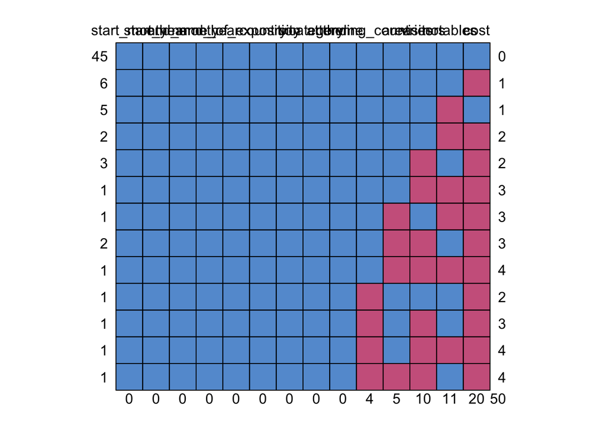

```
   start_month start_year end_month end_year name_of_exposition country city
45           1          1         1        1                  1       1    1
6            1          1         1        1                  1       1    1
5            1          1         1        1                  1       1    1
2            1          1         1        1                  1       1    1
3            1          1         1        1                  1       1    1
1            1          1         1        1                  1       1    1
1            1          1         1        1                  1       1    1
2            1          1         1        1                  1       1    1
1            1          1         1        1                  1       1    1
1            1          1         1        1                  1       1    1
1            1          1         1        1                  1       1    1
1            1          1         1        1                  1       1    1
1            1          1         1        1                  1       1    1
             0          0         0        0                  0       0    0
   category theme attending_countries area visitors notables cost
45        1     1                   1    1        1        1    1  0
6         1     1                   1    1        1        1    0  1
5         1     1                   1    1        1        0    1  1
2         1     1                   1    1        1        0    0  2
3         1     1                   1    1        0        1    0  2
1         1     1                   1    1        0        0    0  3
1         1     1                   1    0        1        0    0  3
2         1     1                   1    0        0        1    0  3
1         1     1                   1    0        0        0    0  4
1         1     1                   0    1        1        1    0  2
1         1     1                   0    1        0        1    0  3
1         1     1                   0    1        0        0    0  4
1         1     1                   0    0        0        1    0  4
          0     0                   4    5       10       11   20 50
```

```r
suppressMessages(library(mice))

#  Show the missing data pattern
md.pattern(worlds_fairs) # Blue is observed, red is missing
```

```r
imputed_data <- mice(worlds_fairs, method = 'pmm', m = 5, maxit = 50)
#imputed_data <- mice(worlds_fairs, method = 'norm', m = 5, maxit = 50) # Gives negative values
#imputed_data <- mice(worlds_fairs, method = 'norm.predict', m = 5, maxit = 50) # Gives negative values
#imputed_data <- mice(worlds_fairs, method = 'mean', m = 5, maxit = 50) # Gives negative values
#imputed_data <- mice(worlds_fairs, method = 'pmm', m = 5, maxit = 50, seed = 1842)
# we are using the Predictive Mean Matching method and we generated 5 different versions of the dataset, each with slightly different imputed values and 50 iterations with random seed 1842

# Inspect the imputed data.
#summary(imputed_data)

# Matrix of the imputed values for the cost variable
imputed_data$imp$cost
```

|  | 1 | 2 | 3 | 4 | 5 |
| --- | --- | --- | --- | --- | --- |
| 18 | 442.50 | 1.14 | 3.55 | 160.00 | 22.80 |
| 24 | 1.70 | 111.00 | 3.55 | 3.55 | 78.40 |
| 26 | 1.14 | 442.50 | 24.70 | 22.40 | 1.70 |
| 29 | 3.55 | 57.25 | 24.70 | 2.30 | 4.50 |
| 30 | 609.52 | 4.00 | 12.00 | 43.40 | 568.75 |
| 31 | 12.00 | 3130.00 | 25.00 | 12.00 | 3130.00 |
| 33 | 160.00 | 5.70 | 8.01 | 160.00 | 5.70 |
| 34 | 58.51 | 25.00 | 27.30 | 642.20 | 2.89 |
| 35 | 58.51 | 1070.00 | 763.70 | 8.01 | 27.30 |
| 36 | 22.40 | 609.52 | 8.01 | 57.25 | 156.00 |

[output cut: 10 more lines]

[figure not shown]

```r
# Visual summary of the imputation process
stripplot(imputed_data)
```

```r
# helps you understand how the imputed values compare to the observed data and whether the imputation seems reasonable.

# Extract the Dataset
worlds_fairs_imputed <- complete(imputed_data,3)

# Compare Before and After
summary(worlds_fairs$cost)
```

```
     Min.   1st Qu.    Median      Mean   3rd Qu.      Max.      NA's
    1.140     8.258    50.325   986.281   634.030 14600.000        20
```

```r
summary(worlds_fairs_imputed$cost)
```

```
    Min.  1st Qu.   Median     Mean  3rd Qu.     Max.
    1.14     8.01    25.00   758.60   537.19 14600.00
```

```r
#skim(worlds_fairs)
#skim(worlds_fairs_imputed)

imputed_fairs <- worlds_fairs_imputed %>% dplyr::select("start_year","country", "city", "cost")
imputed_fairs
```

| start_year | country | city | cost |
| --- | --- | --- | --- |
| 1851 | United Kingdom | London | 1.67 |
| 1855 | France | Paris | 5.70 |
| 1862 | United Kingdom | London | 2.30 |
| 1867 | France | Paris | 4.50 |
| 1873 | Austria-Hungary | Vienna | 12.00 |
| 1876 | United States | Philadelphia | 9.00 |
| 1878 | France | Paris | 11.00 |
| 1880 | Colony of Victoria | Melbourne | 1.56 |
| 1888 | Spain | Barcelona | 1.70 |
| 1889 | France | Paris | 8.01 |

[output cut: 60 more lines]

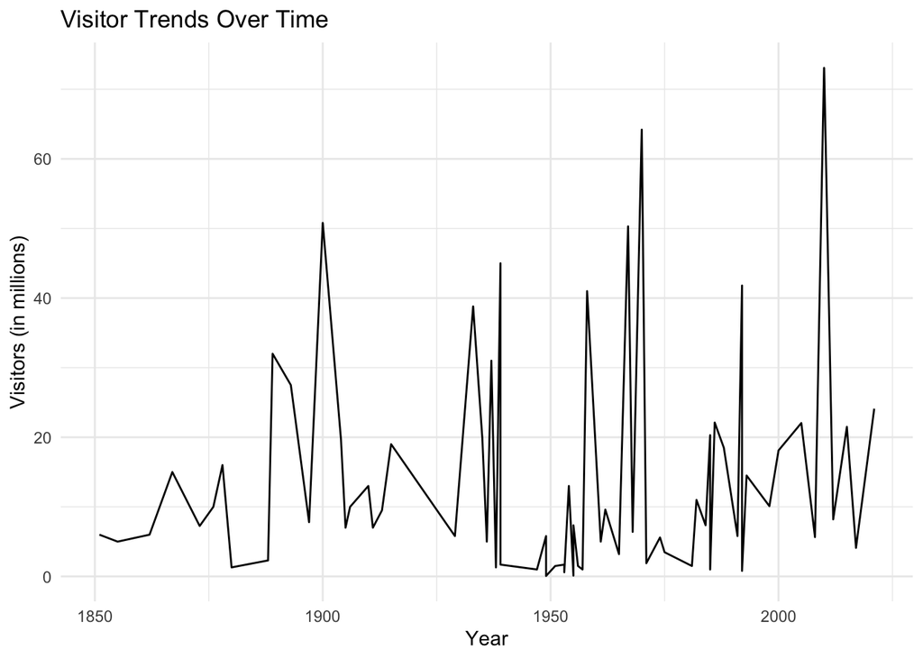

```r
library(ggplot2)

ggplot(worlds_fairs_imputed, aes(x = start_year, y = visitors)) +
  geom_line() +
  labs(title = "Visitor Trends Over Time",
       x = "Year",
       y = "Visitors (in millions)") +
  theme_minimal()
```

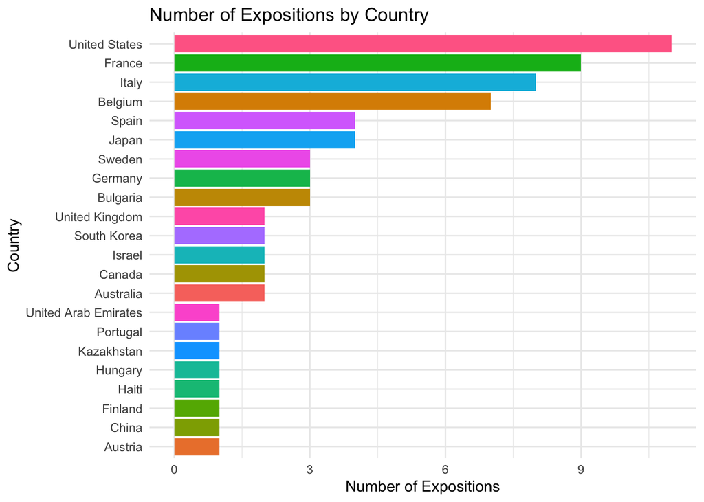

```r
# Rename counties to
worlds_fairs_imputed <- worlds_fairs_imputed %>%
  mutate(country = recode(country, "Colony of Victoria" = "Australia", "West Germany" = "Germany", "People's Republic of China" = "China",  "Austria-Hungary" = "Austria"))


ggplot(worlds_fairs_imputed %>%
         count(country) %>%
         arrange(n),
       aes(x = reorder(country, n), y = n, fill = country)) +
  geom_bar(stat = "identity") +
  coord_flip() +
  labs(title = "Number of Expositions by Country",
       x = "Country",
       y = "Number of Expositions") +
  theme_minimal() +
  theme(legend.position = "none")
```

```r
cost_expositions_df <- worlds_fairs_imputed[, c("cost", "start_year")]

cost_expositions_df
```

| cost | start_year |
| --- | --- |
| 1.67 | 1851 |
| 5.70 | 1855 |
| 2.30 | 1862 |
| 4.50 | 1867 |
| 12.00 | 1873 |
| 9.00 | 1876 |
| 11.00 | 1878 |
| 1.56 | 1880 |
| 1.70 | 1888 |
| 8.01 | 1889 |

[output cut: 60 more lines]

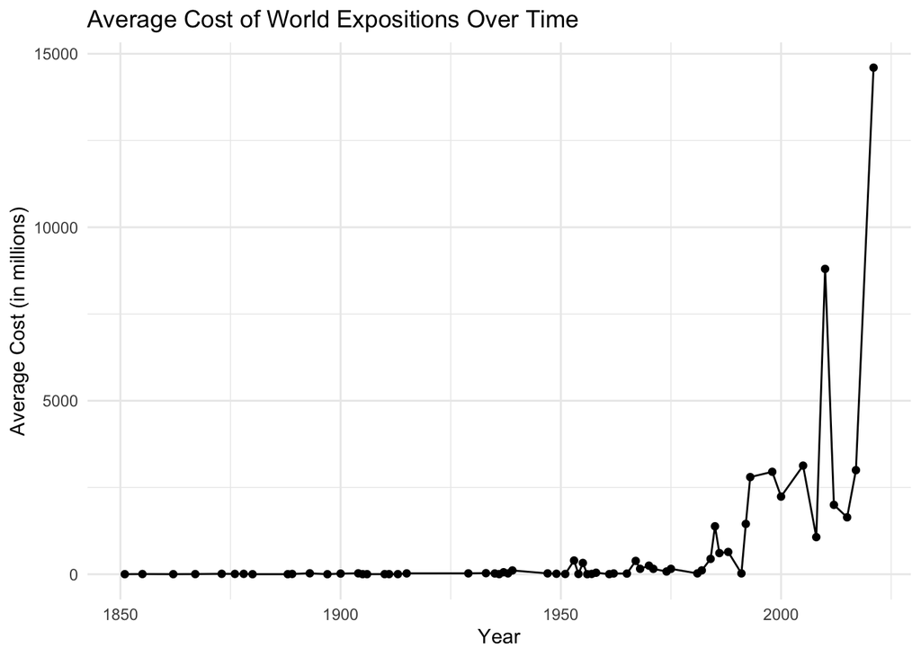

```r
worlds_fairs_imputed %>%
  group_by(start_year) %>%
  summarise(avg_cost = mean(cost, na.rm = TRUE)) %>%
  ggplot(aes(x = start_year, y = avg_cost)) +
  geom_line() +
  geom_point() +
  labs(title = "Average Cost of World Expositions Over Time",
       x = "Year",
       y = "Average Cost (in millions)") +
  theme_minimal()
```

```r
#sessioninfo::session_info(include_base = TRUE)
```

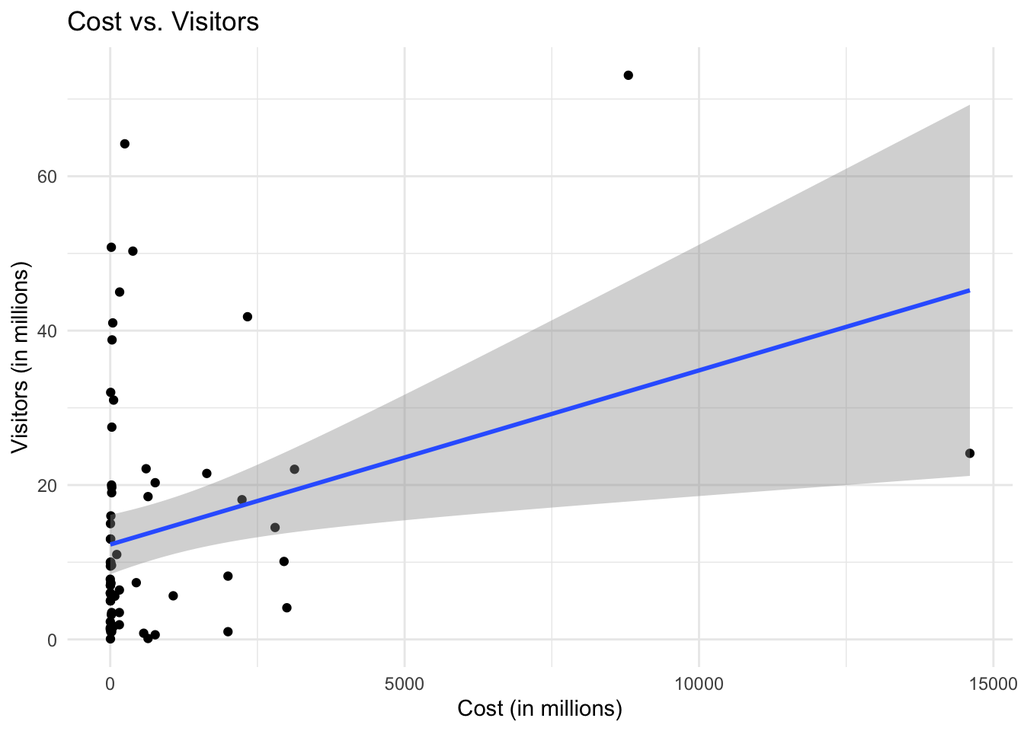

```r
ggplot(worlds_fairs_imputed, aes(x = cost, y = visitors)) +
  geom_point() +
  geom_smooth(method = "lm") +
  labs(title = "Cost vs. Visitors",
       x = "Cost (in millions)",
       y = "Visitors (in millions)") +
  theme_minimal()
```

```r
cost_visitors_df <- worlds_fairs_imputed[, c("cost", "visitors")]

cost_visitors_df
```

| cost | visitors |
| --- | --- |
| 1.67 | 6.000 |
| 5.70 | 5.000 |
| 2.30 | 6.000 |
| 4.50 | 15.000 |
| 12.00 | 7.250 |
| 9.00 | 10.000 |
| 11.00 | 16.000 |
| 1.56 | 1.300 |
| 1.70 | 2.300 |
| 8.01 | 32.000 |

[output cut: 60 more lines]